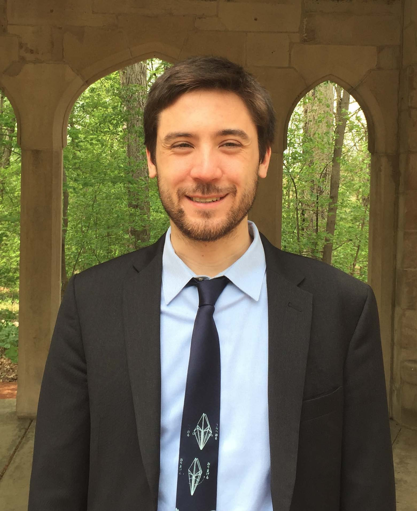

# Eric Langowski

## About Me

*Code is policy.* In government, the choices we make when building systems and analyzing data are policy choices. I work at the intersection of Data Science & Government telling stories which make a difference and bring positive change. I have worked at the city, county, state, and federal levels of government.

My research has been featured in the [New York](https://www.nytimes.com/2021/04/03/opinion/sunday/property-taxes-housing-assessment-inequality.html) [Times](https://www.nytimes.com/2020/06/11/opinion/coronavirus-cities-property-taxes.html), [Washington Post](https://www.washingtonpost.com/business/2021/03/12/property-tax-regressive/), [Bloomberg News](https://www.bloomberg.com/news/features/2021-03-09/racial-inequality-broken-property-tax-system-blocks-black-wealth-building), and other publications.

I am a data scientist, [award-winning historian](https://www.jstor.org/stable/10.2979/indimagahist.115.2.01), [policymaker](https://gitlab.com/users/erhlango/activity), and [educator](https://github.com/erhla/pa470spring2022). I currently work for government as a staff data scientist. I also previously worked on a civic tech tool to automatically file [property tax appeals for low-income homeowners](https://illegalforeclosures.org/), as a data scientist at the [Center for Municipal Finance](https://munifinance.uchicago.edu/), and as an adjunct lecturer at the [University of Illinois Chicago Master of Science in Civic Analytics Program.](https://cuppa.uic.edu/academics/pa/pa-programs/master-of-science-in-civic-analytics/)

I received a Master of Science in Computational Analysis & Public Policy at the University of Chicago in 2020 and a Bachelor of Science in Mathematics from Indiana University in 2018.